# Analysis of simulated data to test for polygenic selection – rrBlup style (Drift)

Timothy Beissinger

5-24-2016

### Run information

**Drift was simulated (No Selection)**

**100 QTL in total (10 per chromosome)**

### Summary

We have been exploring using the sum of allele-frequency-change * allele-substitution-effect in breeding populations as a test for selection on polygenic traits, whether or not individual loci show evidence of a significant association with a trait via selection mapping, GWAS, or QTL mapping. Data-based studies look promising, but to truly evaluate this test statistic we’re exploring simulated data. In this R-markdown file I will load simulation results that involve a selected population with phenotypic data, pre-selection genotypes, and post-selection genotypes. I will estimate SNP effect sizes and also calculate allele frequency change over time, then assess whether or not there is significant evidence of polygenic selection.

### Load simulation data

Simulations were performed on the IRCF biocluster using QMSim.

```r
directory="r_qtl_100_rnd"

pheno <- read.table(paste(directory, "/Line 1_data_001.txt",sep=""),header=T,stringsAsFactors=F)
map <- read.table(paste(directory, "/lm_mrk_001.txt",sep=""),header=T,stringsAsFactors=F)
geno <- read.table(paste(directory, "/Line 1_mrk_001_head.txt",sep=""),header=F,stringsAsFactors=F,skip=1,sep="", colClasses=c("numeric","character")) # read genos as characters
qtlMap <- read.table(paste(directory, "/lm_qtl_001.txt",sep=""),header=T,stringsAsFactors=F)
```

### Manipulate simulation data

Genotype files are in a strange format. Reorganize by coding to -1,0,1 and so that markers are columns, individuals are rows.

```r
gen <- matrix(NA,nrow=nrow(map),ncol=nrow(geno))
gen <- as.data.frame(gen)
names(gen) <- geno[,1]
for(i in 1:1000){
  #print(i)
  tmp <- as.numeric(unlist(strsplit(geno[i,2],split="")))
  tmp[which(tmp == 0)] <- -1
  tmp[which(tmp == 3 | tmp ==4)] <- 0
  tmp[which(tmp==2)] <- 1
  gen[,i] <- tmp
}
gen<-t(gen)
#geno2 <- cbind(as.numeric(rownames(gen)),gen) #gapit genotype file
#rm(gen) # free up memory
#rm(geno)
gc()
```

```
##             used  (Mb) gc trigger   (Mb)  max used   (Mb)
## Ncells    410932  22.0     750400   40.1    488995   26.2
## Vcells 113770755 868.1  376663836 2873.8 313674396 2393.2
```

```r
colnames(gen) <- c(map$ID)
# need to make geno2 a numeric matrix. I think it is character right now :-(
```

### rr-BLUP

At this point, we’ll load rrBLUP and use it to estimate marker effects.

```r
#library(compiler)
#library(MASS)
#source("http://www.zzlab.net/GAPIT/emma.txt")
#source("http://www.zzlab.net/GAPIT/gapit_functions.txt")
#library(multtest)
#library('gplots')
#library('LDheatmap')
#library('genetics')
library(rrBLUP)
#library(scatterplot3d)
```

Now we can begin to run rrBLUP. The first step is to calculate the A matrix and check if any markers need to be imputed

```r
phen <- as.matrix(pheno[,10:13]) # phenos must be a matrix
#impute=A.mat(gen, max.missing=0.5,impute.method="mean",return.imputed=T)
#gen.imputed <- impute$imputed
```

Now we can define the training and validation populations.

```r
train <- sample(1000,600)
test <- setdiff(1:1000,train)
Pheno_train <- phen[train,4] ###
m_train <- gen[train,]
Pheno_valid <- phen[test,4] ###
m_valid <- gen[test,]
```

So far so good. Now it is time to run mixed.solve to do the genomic prediction using rr_blup and then validate.

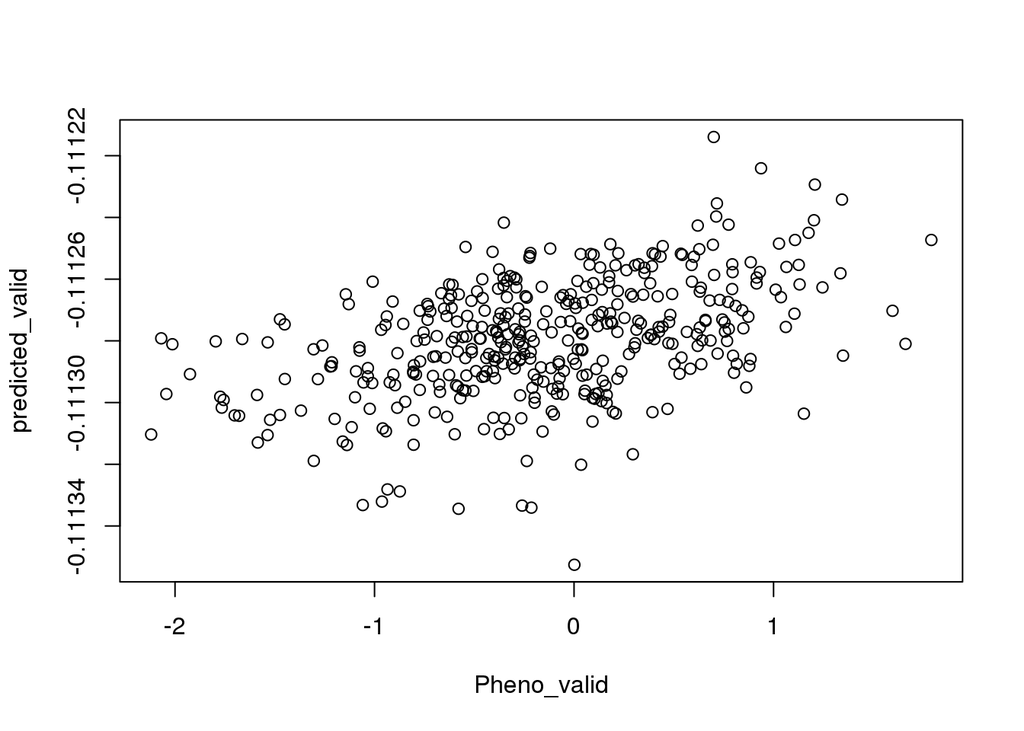

```r
answer <- mixed.solve(Pheno_train, Z=m_train, K=NULL, SE=F, return.Hinv=FALSE, method="ML")
effects <- answer$u
effects.mat = as.matrix(effects)

# validate
pred_phen_valid <- m_valid %*% effects.mat
predicted_valid <- (pred_phen_valid[,1] + answer$beta)
#predicted_valid
plot(Pheno_valid,predicted_valid)
```

```r
cor(Pheno_valid,predicted_valid)
```

```
## [1] 0.4501226
```

Check how overfit the model is…

```r
pred_phen_train = m_train %*% effects.mat
predicted_train = pred_phen_train[,1] +answer$beta
cor(Pheno_train, predicted_train)
```

```
## [1] 0.8751679
```

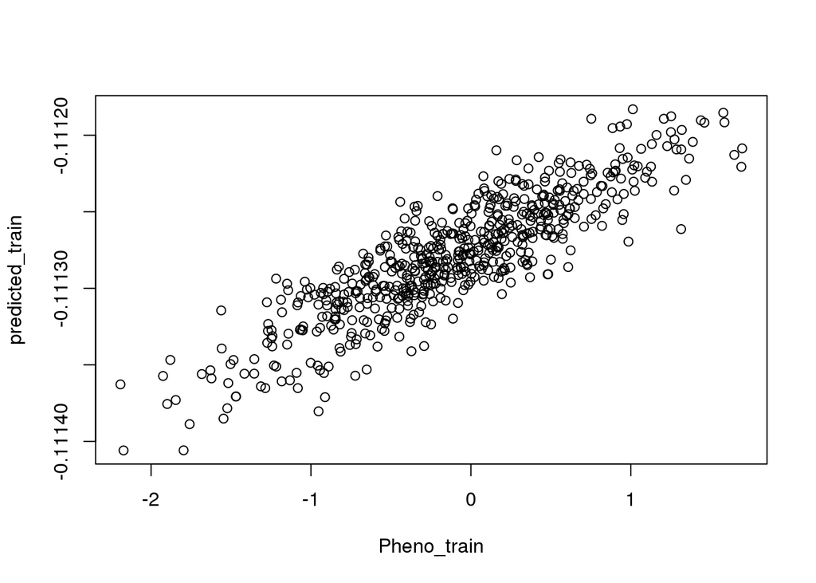

```r
plot(Pheno_train, predicted_train)
```

Next up, we should calculate allele frequencies

```r
freqs0<-read.table(paste(directory, "/Line 1_freq_mrk_001.txt",sep=""),header=T,nrows=length(effects),fill=T,stringsAsFactors=F)
names(freqs0)[4]<- "Allele1"
names(freqs0)[5]<- "Allele2"
freqs0$Allele2[which(substr(freqs0$Allele1,1,1)==2)] <- "2:1.00000" # put this in the spot for the second allele
freqs0$Allele1[which(substr(freqs0$Allele1,1,1)==2)] <- "1:0.00000"
freqs0$Allele1 <- as.numeric(substr(freqs0$Allele1,3,1000))
freqs0$Allele2 <- as.numeric(substr(freqs0$Allele2,3,1000))

freqs20<-read.table(paste(directory, "/Line 1_freq_mrk_001.txt",sep=""),header=F,skip={4*length(effects)+1},fill=T,stringsAsFactors=F)
names(freqs20)[4]<- "Allele1"
names(freqs20)[5]<- "Allele2"
freqs20$Allele2[which(substr(freqs20$Allele1,1,1)==2)] <- "2:1.00000" # put this in the spot for the second allele
freqs20$Allele1[which(substr(freqs20$Allele1,1,1)==2)] <- "1:0.00000"
freqs20$Allele1 <- as.numeric(substr(freqs20$Allele1,3,1000))
freqs20$Allele2 <- as.numeric(substr(freqs20$Allele2,3,1000))
```

## Excitement! Now we can look at the correlation of change and effect size

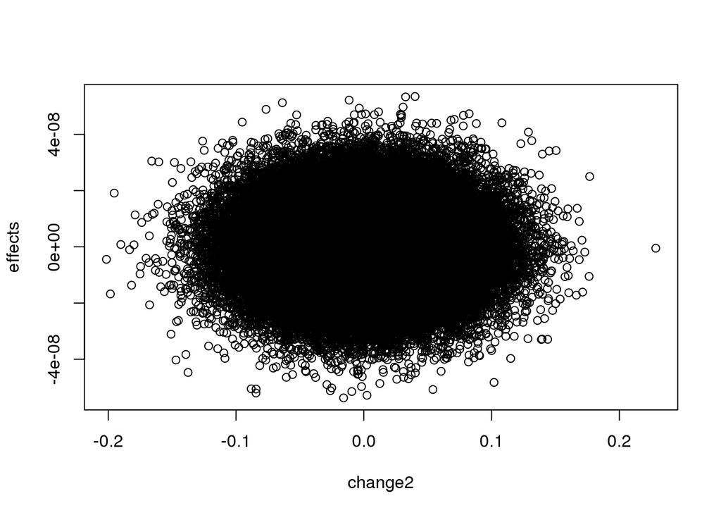

```r
change1<-freqs20$Allele1-freqs0$Allele1
change2<-freqs20$Allele2-freqs0$Allele2

plot(change2,effects)
```

```r
cor.test(change2, effects,use="pairwise.complete.obs")
```

```
##
##  Pearson's product-moment correlation
##
## data:  change2 and effects
## t = 0.60735, df = 99731, p-value = 0.5436
## alternative hypothesis: true correlation is not equal to 0
## 95 percent confidence interval:
##  -0.004283119  0.008129345
## sample estimates:
##         cor
## 0.001923187
```

## Now we can compute our test statistic, do a permutation test, and make a manhattan plot

```r
# First, compute three statistics of interest
Qstat <- change2 * effects
Qstat_corrected <- abs(change2 * effects)/(freqs0$Allele2*(1-freqs0$Allele2))
Qstat_genome <- sum(change2*effects, na.rm=T)
Qstat_genome
```

```
## [1] 9.704777e-08
```

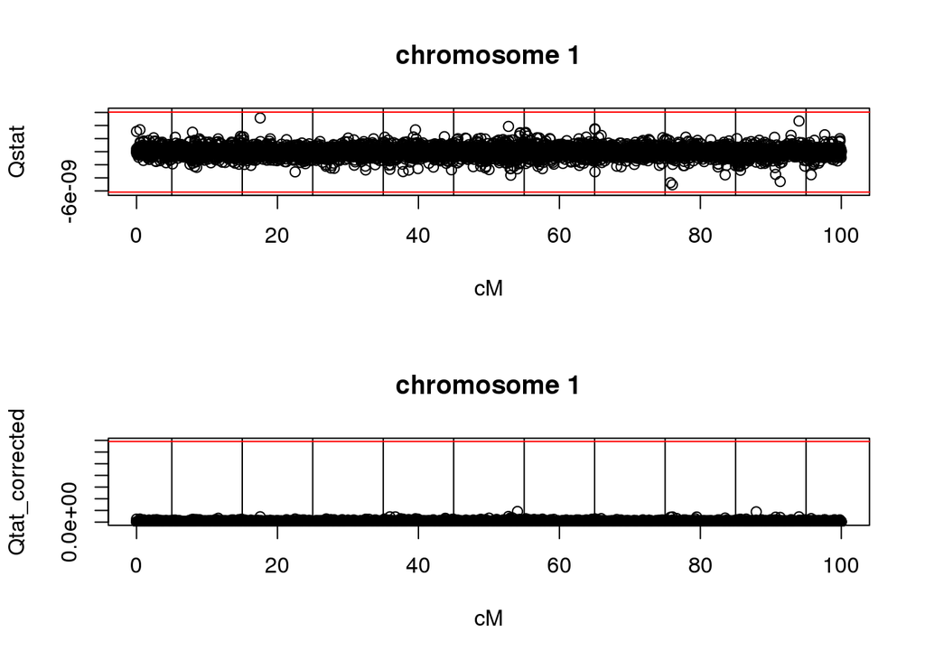

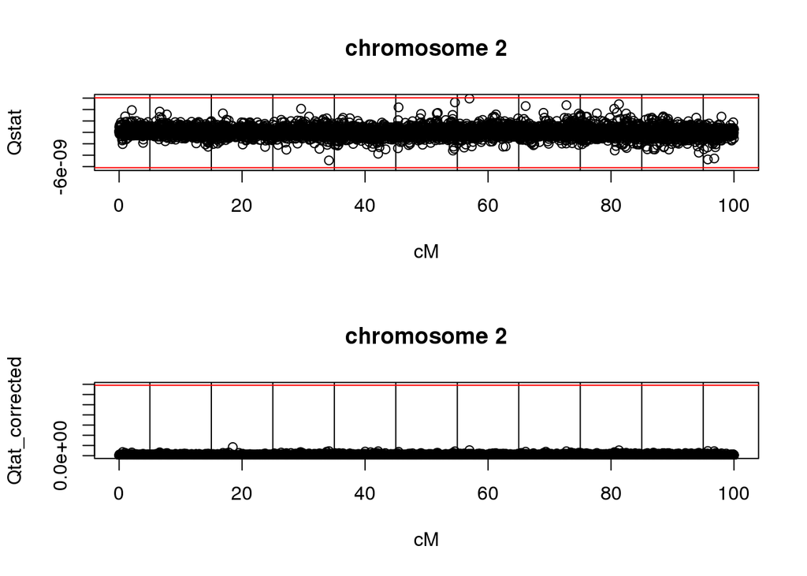

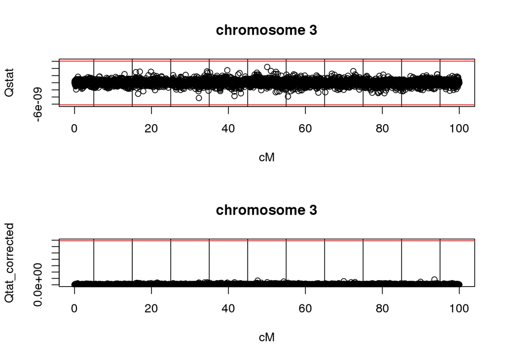

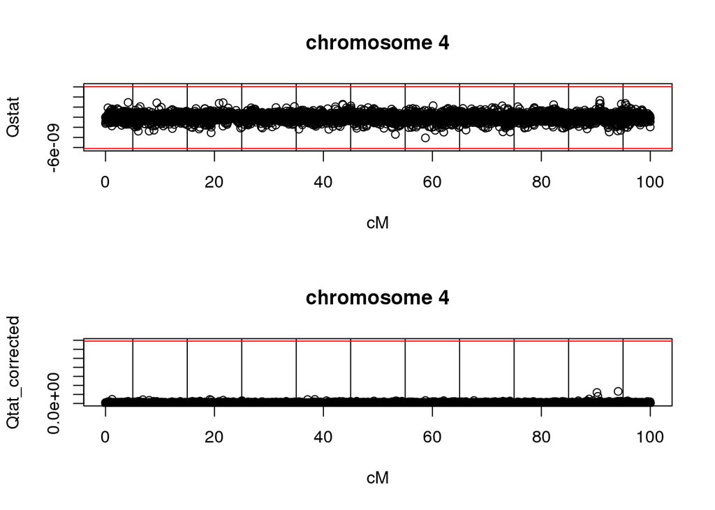

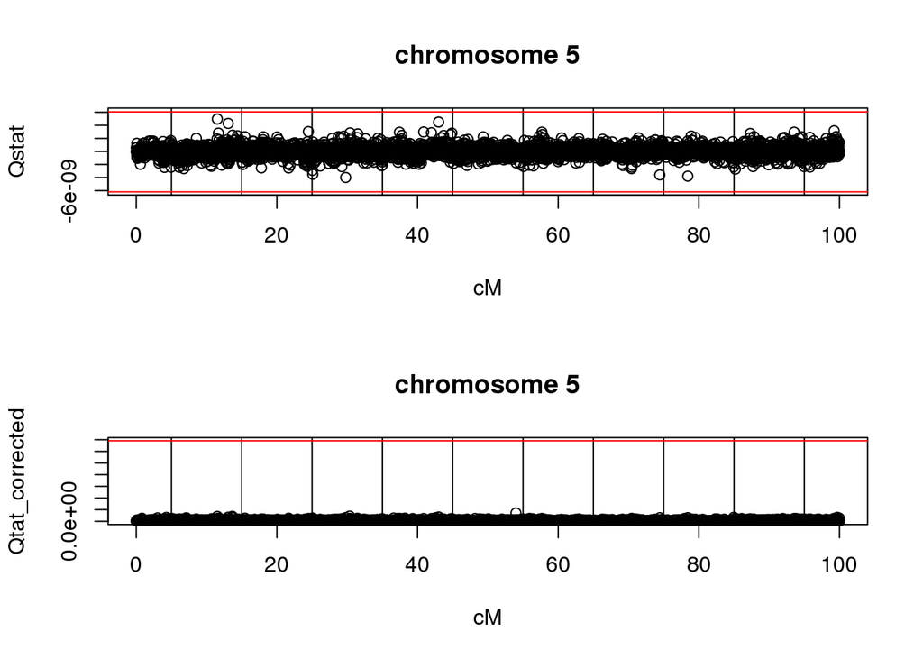

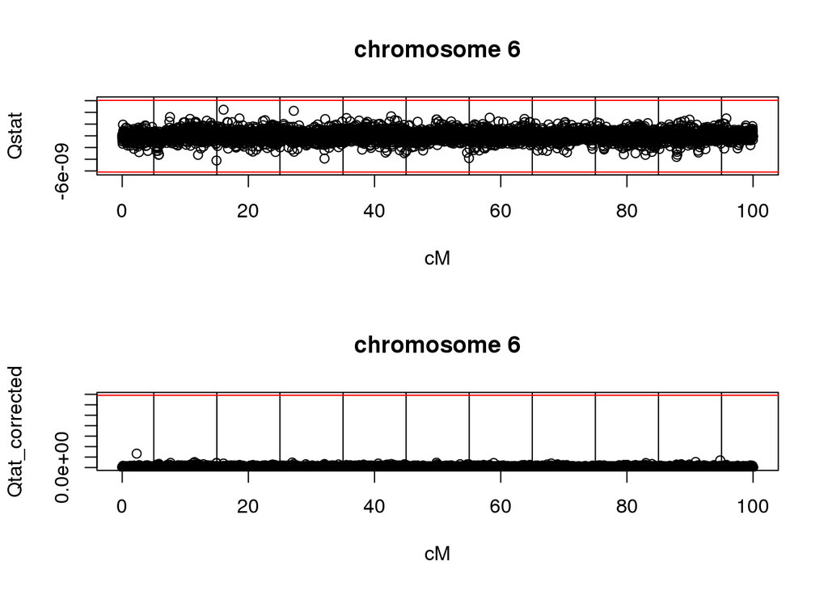

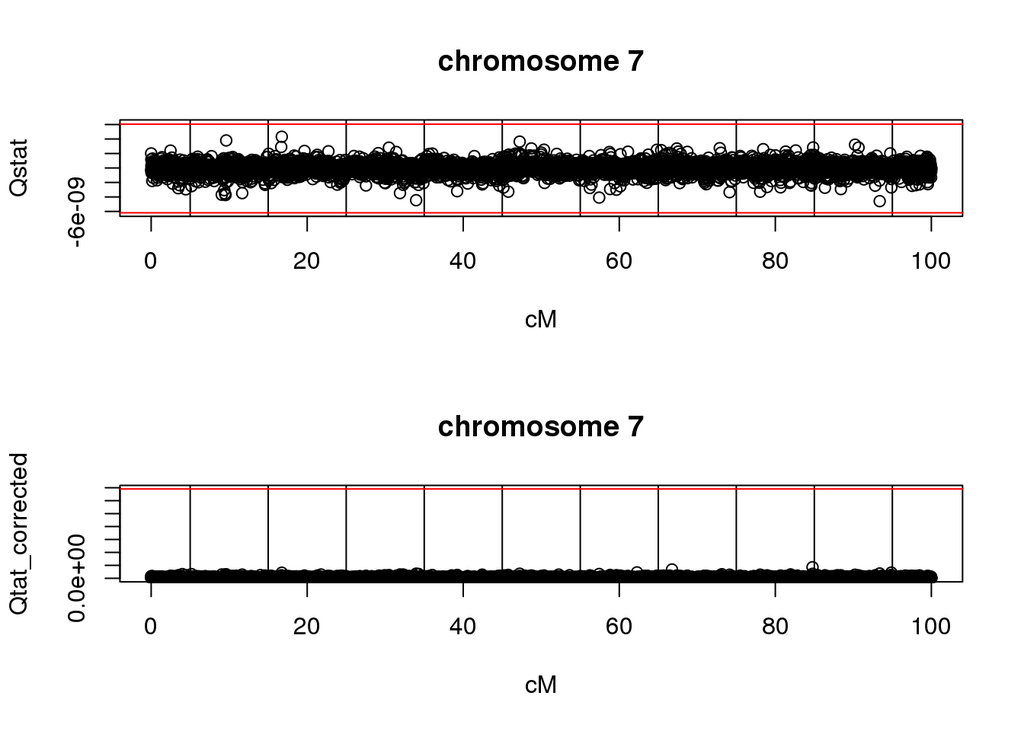

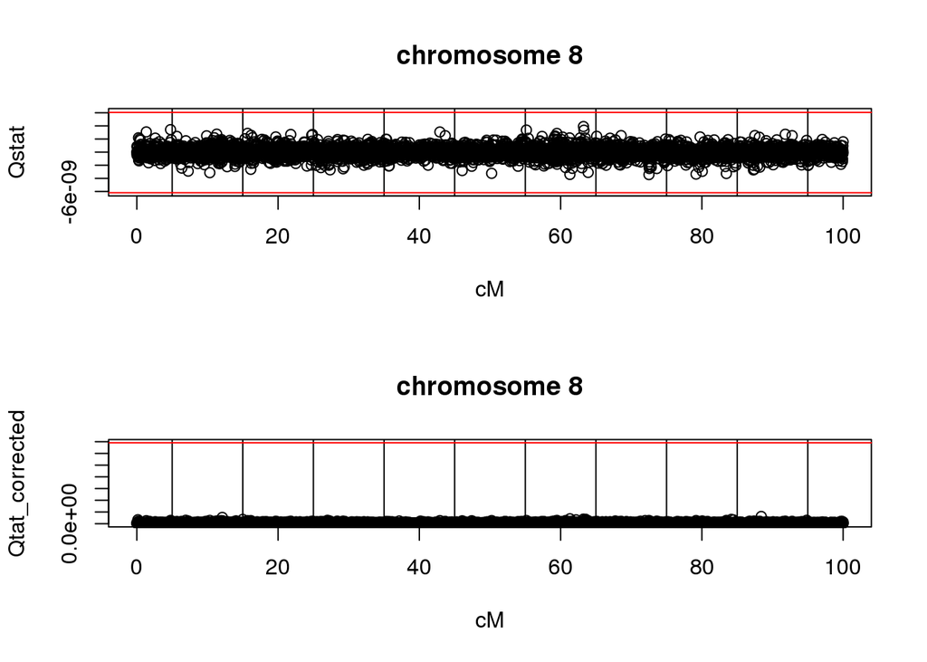

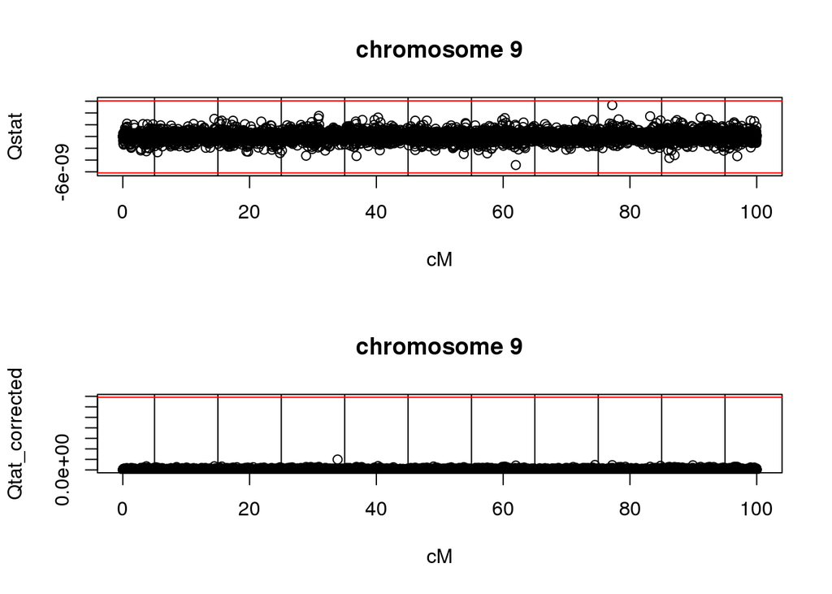

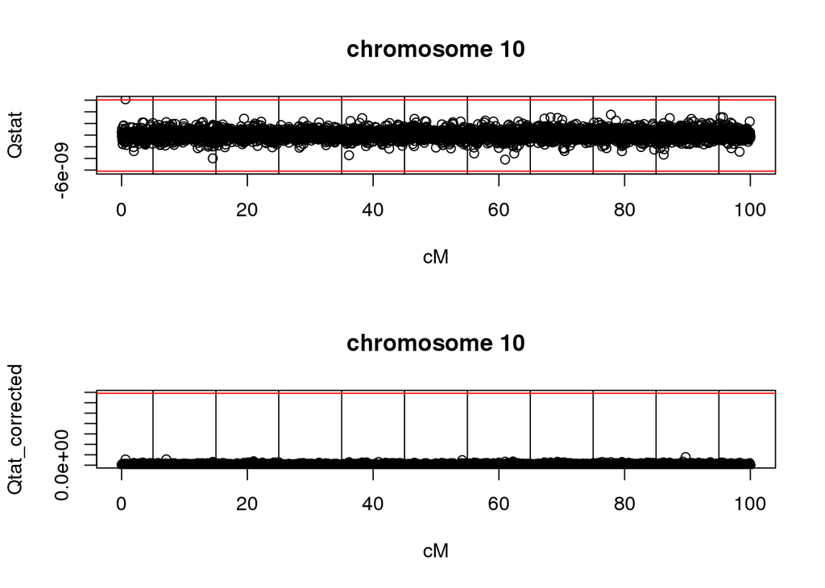

```r
# Now do the permutation test
Qstat_perm_high<-c()
Qstat_perm_low<-c()
Qstat_corrected_perm_high <- c()

Qstat_genome_shuffled <- c()

for(i in 1:1000){
  #print(i)
  change2_index <- sample(length(change2),length(change2),replace=F)
  change2_shuffle <- change2[change2_index]
  freqs0_Allele2_shuffle <- freqs0$Allele2[change2_index]
  effects_shuffle <- sample(effects,length(effects),replace=F)

  Qstat_shuffle <- change2_shuffle*effects_shuffle
  Qstat_corrected_shuffle <- abs(change2_shuffle*effects_shuffle)/(freqs0_Allele2_shuffle *(1-freqs0_Allele2_shuffle))

  Qstat_perm_high[i] <- quantile(Qstat_shuffle,0.99999,na.rm=T)
  Qstat_perm_low[i] <- quantile(Qstat_shuffle,0.00001,na.rm=T)
  Qstat_corrected_perm_high[i] <- quantile(Qstat_corrected_shuffle,0.99999,na.rm=T)

  Qstat_genome_shuffled[i] <- sum(Qstat_shuffle,na.rm=T)
}

Qstat_upper <- quantile(Qstat_perm_high,0.975)
Qstat_lower <- quantile(Qstat_perm_low,0.025)
Qstat_corrected_upper <- quantile(Qstat_corrected_perm_high,0.975)


for(i in 1:10){
start<-i*10000-9999
end<-i*10000
par(mfrow=c(2,1))
plot(map$Position[start:end],Qstat[start:end],ylab="Qstat", xlab="cM",main=paste("chromosome", i),ylim=c(min(Qstat,Qstat_lower,na.rm=T),max(Qstat,Qstat_upper,na.rm=T)))
abline(v=qtlMap$Position[1:10])
abline(h=c(Qstat_upper,Qstat_lower),col="red")

plot(map$Position[start:end],Qstat_corrected[start:end],ylab="Qtat_corrected",xlab="cM",main=paste("chromosome", i),ylim=c(0,max(Qstat_corrected,Qstat_corrected_upper,na.rm=T)))
abline(v=qtlMap$Position[1:10])
abline(h=Qstat_corrected_upper,col="red")
}
```

```r
#Overall data
hist(Qstat_genome_shuffled,xlim=c(min(Qstat_genome,Qstat_genome_shuffled,na.rm=T),max(Qstat_genome,Qstat_genome_shuffled,na.rm=T)))
abline(v=Qstat_genome)

length(which(Qstat>=Qstat_upper | Qstat <= Qstat_lower)) # Number Qstat outliers
```

```
## [1] 1
```

```r
length(which(Qstat_corrected>=Qstat_corrected_upper)) # Number Qstat_corrected outliers
```

```
## [1] 0
```

```r
length(which(abs(Qstat_genome_shuffled) >= abs(Qstat_genome))) / length(Qstat_genome_shuffled) # Qstat_genome p-value
```

```
## [1] 0.525
```

[figure not shown]